**Fully Convolutional Networks for Segmentation**

By Prof. Seungchul Lee  
http://iai.postech.ac.kr/  
Industrial AI Lab at POSTECH

Table of Contents

# 1. Segmentation

[figure not shown]

- Segmentation task is different from classification task because it requires predicting a class for each pixel of the input image, instead of only 1 class for the whole input.
- Classification needs to understand what is in the input (namely, the context).
- However, in order to predict what is in the input for each pixel, segmentation needs to recover not only what is in the input, but also where.
- Segment images into regions with different semantic categories. These semantic regions label and predict objects at the pixel level

# 2. Fully Convolutional Networks (FCN)

[figure not shown]

- FCN is built only from locally connected layers, such as convolution, pooling and upsampling.
- Note that no dense layer is used in this kind of architecture.
- Network can work regardless of the original image size, without requiring any fixed number of units at any stage.
- To obtain a segmentation map (output), segmentation networks usually have 2 parts
  - Downsampling path: capture semantic/contextual information
  - Upsampling path: recover spatial information
- The downsampling path is used to extract and interpret the context (what), while the upsampling path is used to enable precise localization (where).
- Furthermore, to fully recover the fine-grained spatial information lost in the pooling or downsampling layers, we often use skip connections.
- Given a position on the spatial dimension, the output of the channel dimension will be a category prediction of the pixel corresponding to the location.

# 3. Supervised Learning for Segmentation

## 3.1. Segmented (Labeled) Images

Download data from [here](https://www.dropbox.com/s/24okrd00jfj5qot/FCN_lecture_data_files.zip?dl=1)

```python
import numpy as np
import matplotlib.pyplot as plt
import scipy

import tensorflow as tf
from keras.applications.vgg16 import VGG16
```

```python
train_imgs = np.load('./data_files/images_training.npy')
train_seg = np.load('./data_files/seg_training.npy')
test_imgs = np.load('./data_files/images_testing.npy')

n_train = train_imgs.shape[0]
n_test = test_imgs.shape[0]

print ("The number of training images : {}, shape : {}".format(n_train, train_imgs.shape))
print ("The number of testing images : {}, shape : {}".format(n_test, test_imgs.shape))
```

```
The number of training images : 289, shape : (289, 160, 576, 3)
The number of testing images : 290, shape : (290, 160, 576, 3)
```

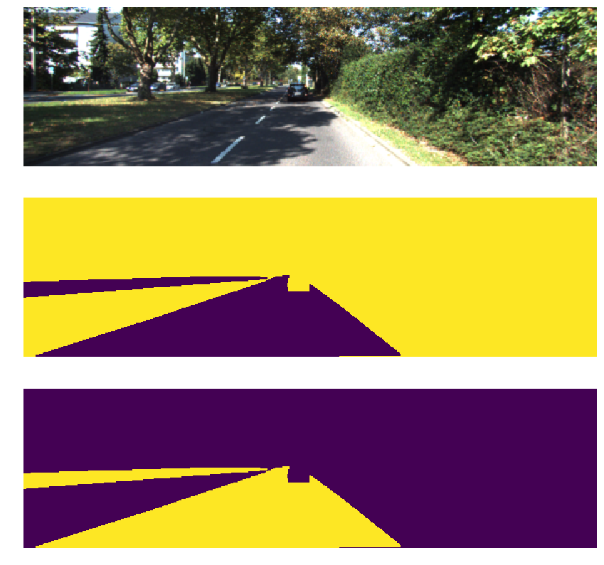

```python
idx = np.random.randint(n_train)

plt.figure(figsize = (16,14))
plt.subplot(3,1,1)
plt.imshow(train_imgs[idx])
plt.axis('off')
plt.subplot(3,1,2)
plt.imshow(train_seg[idx][:,:,0])
plt.axis('off')
plt.subplot(3,1,3)
plt.imshow(train_seg[idx][:,:,1])
plt.axis('off')
plt.show()
```

## 3.2. From CAE to FCN

- CAE

[figure not shown]

- FCN
  - VGG16
  - Skip connections to fully recover the fine-grained spatial information lost in the pooling or downsampling layers

[figure not shown]

# 4. FCN Implementation

[figure not shown]

## 4.1. Utilize VGG16 Model for Encoder

```python
model = VGG16(weights = 'imagenet')

model.summary()
```

```
_________________________________________________________________
Layer (type)                 Output Shape              Param #
=================================================================
input_1 (InputLayer)         (None, 224, 224, 3)       0
_________________________________________________________________
block1_conv1 (Conv2D)        (None, 224, 224, 64)      1792
_________________________________________________________________
block1_conv2 (Conv2D)        (None, 224, 224, 64)      36928
_________________________________________________________________
block1_pool (MaxPooling2D)   (None, 112, 112, 64)      0
_________________________________________________________________
block2_conv1 (Conv2D)        (None, 112, 112, 128)     73856
_________________________________________________________________
block2_conv2 (Conv2D)        (None, 112, 112, 128)     147584
_________________________________________________________________
block2_pool (MaxPooling2D)   (None, 56, 56, 128)       0
_________________________________________________________________
block3_conv1 (Conv2D)        (None, 56, 56, 256)       295168
_________________________________________________________________
block3_conv2 (Conv2D)        (None, 56, 56, 256)       590080
_________________________________________________________________
block3_conv3 (Conv2D)        (None, 56, 56, 256)       590080
_________________________________________________________________
block3_pool (MaxPooling2D)   (None, 28, 28, 256)       0
_________________________________________________________________
block4_conv1 (Conv2D)        (None, 28, 28, 512)       1180160
_________________________________________________________________
block4_conv2 (Conv2D)        (None, 28, 28, 512)       2359808
_________________________________________________________________
block4_conv3 (Conv2D)        (None, 28, 28, 512)       2359808
_________________________________________________________________
block4_pool (MaxPooling2D)   (None, 14, 14, 512)       0
_________________________________________________________________
block5_conv1 (Conv2D)        (None, 14, 14, 512)       2359808
_________________________________________________________________
block5_conv2 (Conv2D)        (None, 14, 14, 512)       2359808
_________________________________________________________________
block5_conv3 (Conv2D)        (None, 14, 14, 512)       2359808
_________________________________________________________________
block5_pool (MaxPooling2D)   (None, 7, 7, 512)         0
_________________________________________________________________
flatten (Flatten)            (None, 25088)             0
_________________________________________________________________
fc1 (Dense)                  (None, 4096)              102764544
_________________________________________________________________
fc2 (Dense)                  (None, 4096)              16781312
_________________________________________________________________
predictions (Dense)          (None, 1000)              4097000
=================================================================
Total params: 138,357,544
Trainable params: 138,357,544
Non-trainable params: 0
_________________________________________________________________
```

```python
vgg16_weights = model.get_weights()

weights = {
    'conv1_1' : tf.constant(vgg16_weights[0]),
    'conv1_2' : tf.constant(vgg16_weights[2]),

    'conv2_1' : tf.constant(vgg16_weights[4]),
    'conv2_2' : tf.constant(vgg16_weights[6]),

    'conv3_1' : tf.constant(vgg16_weights[8]),
    'conv3_2' : tf.constant(vgg16_weights[10]),
    'conv3_3' : tf.constant(vgg16_weights[12]),

    'conv4_1' : tf.constant(vgg16_weights[14]),
    'conv4_2' : tf.constant(vgg16_weights[16]),
    'conv4_3' : tf.constant(vgg16_weights[18]),

    'conv5_1' : tf.constant(vgg16_weights[20]),
    'conv5_2' : tf.constant(vgg16_weights[22]),
    'conv5_3' : tf.constant(vgg16_weights[24]),
}

biases = {
    'conv1_1' : tf.constant(vgg16_weights[1]),
    'conv1_2' : tf.constant(vgg16_weights[3]),

    'conv2_1' : tf.constant(vgg16_weights[5]),
    'conv2_2' : tf.constant(vgg16_weights[7]),

    'conv3_1' : tf.constant(vgg16_weights[9]),
    'conv3_2' : tf.constant(vgg16_weights[11]),
    'conv3_3' : tf.constant(vgg16_weights[13]),

    'conv4_1' : tf.constant(vgg16_weights[15]),
    'conv4_2' : tf.constant(vgg16_weights[17]),
    'conv4_3' : tf.constant(vgg16_weights[19]),

    'conv5_1' : tf.constant(vgg16_weights[21]),
    'conv5_2' : tf.constant(vgg16_weights[23]),
    'conv5_3' : tf.constant(vgg16_weights[25]),
}

# input layer and output layer
x = tf.placeholder(tf.float32, [None, 160, 576, 3])
y = tf.placeholder(tf.float32, [None, 160, 576, 2])
```

## 4.2. Build a FCN Model

- tf.layers are used to define upsampling parts

```python
def fcn(x, weights, biases):
    # First convolution layers
    conv1_1 = tf.nn.conv2d(x,
                         weights['conv1_1'],
                         strides = [1, 1, 1, 1],
                         padding = 'SAME')
    conv1_1 = tf.nn.relu(tf.add(conv1_1, biases['conv1_1']))
    conv1_2 = tf.nn.conv2d(conv1_1,
                         weights['conv1_2'],
                         strides = [1, 1, 1, 1],
                         padding = 'SAME')
    conv1_2 = tf.nn.relu(tf.add(conv1_2, biases['conv1_2']))
    maxp1 = tf.nn.max_pool(conv1_2,
                           ksize = [1, 2, 2, 1],
                           strides = [1, 2, 2, 1],
                           padding = 'VALID')

    # Second convolution layers
    conv2_1 = tf.nn.conv2d(maxp1,
                         weights['conv2_1'],
                         strides = [1, 1, 1, 1],
                         padding = 'SAME')
    conv2_1 = tf.nn.relu(tf.add(conv2_1, biases['conv2_1']))
    conv2_2 = tf.nn.conv2d(conv2_1,
                         weights['conv2_2'],
                         strides = [1, 1, 1, 1],
                         padding = 'SAME')
    conv2_2= tf.nn.relu(tf.add(conv2_2, biases['conv2_2']))
    maxp2 = tf.nn.max_pool(conv2_2,
                           ksize = [1, 2, 2, 1],
                           strides = [1, 2, 2, 1],
                           padding = 'VALID')

    # third convolution layers
    conv3_1 = tf.nn.conv2d(maxp2,
                         weights['conv3_1'],
                         strides = [1, 1, 1, 1],
                         padding = 'SAME')
    conv3_1 = tf.nn.relu(tf.add(conv3_1, biases['conv3_1']))
    conv3_2 = tf.nn.conv2d(conv3_1,
                         weights['conv3_2'],
                         strides = [1, 1, 1, 1],
                         padding = 'SAME')
    conv3_2= tf.nn.relu(tf.add(conv3_2, biases['conv3_2']))
    conv3_3 = tf.nn.conv2d(conv3_2,
                         weights['conv3_3'],
                         strides = [1, 1, 1, 1],
                         padding = 'SAME')
    conv3_3= tf.nn.relu(tf.add(conv3_3, biases['conv3_3']))
    maxp3 = tf.nn.max_pool(conv3_3,
                           ksize = [1, 2, 2, 1],
                           strides = [1, 2, 2, 1],
                           padding = 'VALID')

    # fourth convolution layers
    conv4_1 = tf.nn.conv2d(maxp3,
                         weights['conv4_1'],
                         strides = [1, 1, 1, 1],
                         padding = 'SAME')
    conv4_1 = tf.nn.relu(tf.add(conv4_1, biases['conv4_1']))
    conv4_2 = tf.nn.conv2d(conv4_1,
                         weights['conv4_2'],
                         strides = [1, 1, 1, 1],
                         padding = 'SAME')
    conv4_2= tf.nn.relu(tf.add(conv4_2, biases['conv4_2']))
    conv4_3 = tf.nn.conv2d(conv4_2,
                         weights['conv4_3'],
                         strides = [1, 1, 1, 1],
                         padding = 'SAME')
    conv4_3= tf.nn.relu(tf.add(conv4_3, biases['conv4_3']))
    maxp4 = tf.nn.max_pool(conv4_3,
                           ksize = [1, 2, 2, 1],
                           strides = [1, 2, 2, 1],
                           padding = 'VALID')

    # fifth convolution layers
    conv5_1 = tf.nn.conv2d(maxp4,
                         weights['conv5_1'],
                         strides = [1, 1, 1, 1],
                         padding = 'SAME')
    conv5_1 = tf.nn.relu(tf.add(conv5_1, biases['conv5_1']))
    conv5_2 = tf.nn.conv2d(conv5_1,
                         weights['conv5_2'],
                         strides = [1, 1, 1, 1],
                         padding = 'SAME')
    conv5_2= tf.nn.relu(tf.add(conv5_2, biases['conv5_2']))
    conv5_3 = tf.nn.conv2d(conv5_2,
                         weights['conv5_3'],
                         strides = [1, 1, 1, 1],
                         padding = 'SAME')
    conv5_3= tf.nn.relu(tf.add(conv5_3, biases['conv5_3']))
    maxp5 = tf.nn.max_pool(conv5_3,
                           ksize = [1, 2, 2, 1],
                           strides = [1, 2, 2, 1],
                           padding = 'VALID')

    # sixth convolution layer
    conv6 = tf.layers.conv2d(maxp5,
                            filters = 4096,
                            kernel_size = 7,
                            padding = 'SAME',
                            activation = tf.nn.relu)

    # 1x1 convolution layers
    fcn4 = tf.layers.conv2d(conv6,
                            filters = 4096,
                            kernel_size = 1,
                            padding = 'SAME',
                            activation = tf.nn.relu)
    fcn3 = tf.layers.conv2d(fcn4,
                            filters = 2,
                            kernel_size = 1,
                            padding = 'SAME')

    # Upsampling layers
    fcn2 = tf.layers.conv2d_transpose(fcn3,
                                      filters = 512,
                                      kernel_size = 4,
                                      strides = (2, 2),
                                      padding = 'SAME')

    fcn1 = tf.layers.conv2d_transpose(fcn2 + maxp4,
                                      filters = 256,
                                      kernel_size = 4,
                                      strides = (2, 2),
                                      padding = 'SAME')

    output = tf.layers.conv2d_transpose(fcn1 + maxp3,
                                     filters = 2,
                                     kernel_size = 16,
                                     strides = (8, 8),
                                     padding = 'SAME')

    return output
```

## 4.3. Training

```python
LR  = 0.001

pred = fcn(x, weights, biases)
logits = tf.reshape(pred, (-1, 2))
labels = tf.reshape(y, (-1, 2))

loss = tf.nn.softmax_cross_entropy_with_logits(logits = logits, labels = labels)
loss = tf.reduce_mean(loss)

optm  = tf.train.AdamOptimizer(LR).minimize(loss)
```

```python
def train_batch_maker(batch_size):
    random_idx = np.random.randint(n_train, size = batch_size)
    return train_imgs[random_idx], train_seg[random_idx]
```

```python
def test_batch_maker(batch_size):
    random_idx = np.random.randint(n_test, size = batch_size)
    return test_imgs[random_idx]
```

```
Epoch : 0
Cost : 1.7055566310882568
Epoch : 30
Cost : 0.18152792751789093
Epoch : 60
Cost : 0.09820426255464554
Epoch : 90
Cost : 0.09158726781606674
Epoch : 120
Cost : 0.07280843704938889
Epoch : 150
Cost : 0.05213502421975136
Epoch : 180
Cost : 0.043223317712545395
Epoch : 210
Cost : 0.03678952902555466
Epoch : 240
Cost : 0.034773096442222595
Epoch : 270
Cost : 0.0343504324555397
```

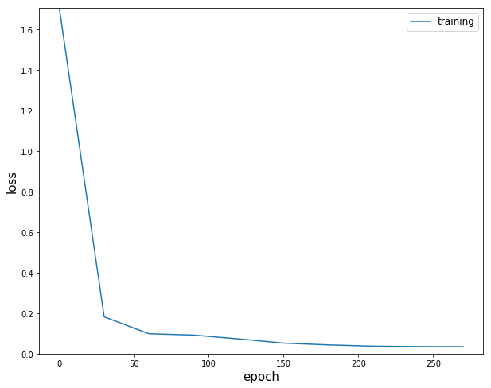

```python
n_batch = 20
n_epoch = 300
n_prt = 30

sess = tf.Session()
sess.run(tf.global_variables_initializer())

loss_record_train = []
for epoch in range(n_epoch):
    train_x, train_y = train_batch_maker(n_batch)
    sess.run(optm, feed_dict = {x: train_x, y: train_y})

    if epoch % n_prt == 0:
        c = sess.run(loss, feed_dict = {x: train_x, y: train_y})
        loss_record_train.append(c)
        print ("Epoch : {}".format(epoch))
        print ("Cost : {}".format(c))

plt.figure(figsize = (10,8))
plt.plot(np.arange(len(loss_record_train))*n_prt, loss_record_train, label = 'training')
plt.xlabel('epoch', fontsize = 15)
plt.ylabel('loss', fontsize = 15)
plt.legend(fontsize = 12)
plt.ylim([0, np.max(loss_record_train)])
plt.show()
```

## 4.4. Testing

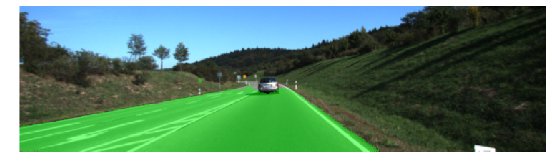

```python
test_x = test_batch_maker(1)

test_img = sess.run(tf.nn.softmax(logits), feed_dict = {x: test_x})
test_img = test_img[:, 1].reshape(160, 576)
segmentation = (test_img > 0.5).reshape(160, 576, 1)

mask = np.dot(segmentation, np.array([[0, 255, 0, 127]]))
mask = scipy.misc.toimage(mask, mode = "RGBA")
street_im = scipy.misc.toimage(test_x[0])
street_im.paste(mask, box = None, mask = mask)

plt.figure(figsize = (16,8))
plt.imshow(street_im)
plt.axis('off')
plt.show()
```

```python
%%javascript
$.getScript('https://kmahelona.github.io/ipython_notebook_goodies/ipython_notebook_toc.js')
```